# Introduction à R

# Le langage R

R est un langage de programmation open source multiplateforme spécialisé dans le traitement et l’analyse de données. Son classement en avril 2020, comme le dixième langage le plus populaire au monde, selon l’index [TIOBE](https://www.tiobe.com/tiobe-index/), traduit son importance comme outil de traitement des données et son développement très actif.

R est une implémentation du langage de programmation S spécialisé dans les statistiques, créé par John Chambers en 1976, combiné au langage Scheme. Il existe des différences importantes entre R et S, mais une grande partie du code écrit pour S s’exécute sans modification dans R. Le langage est développé à partir de 1992 par Ross Ihaka et Robert Gentleman à l’Université d’Auckland. La première version officielle est publiée en 2000.

## Interface

Le langage R possède une interface (*GUI*) limitée qui n’a plus vocation à être directement utilisée. L’utilisateur interagit avec R à travers l’environnement de développement R Studio.

## Evolutivité

Les capacités de R sont étendues grâce à des packages créés par les utilisateurs. Un ensemble de packages de base est inclus avec l’installation de R et plus de 15500 packages supplémentaires (en date d’avril 2020 ) sont disponibles sur le dépôt [CRAN](https://cran.r-project.org/web/packages/).

## Références

### Utilisation de R en Histoire

- https://programminghistorian.org/en/lessons/

### Références générales

- https://en.wikipedia.org/wiki/R_(programming_language)
- https://rss.onlinelibrary.wiley.com/doi/epdf/10.1111/j.1740-9713.2018.01169.x

## Installation

### R et R studio

⚠️ Vous devez d’abord installer R avant d’installer R Studio.

### Installer R (Windows et MacOsX)

Pour une installation sous Windows ou OSX, vous devez vous rendre sur la page **Page d’accueil** du [projet R](https://www.r-project.org/) puis sélectionnez **Download Cran** suivi de **0-Cloud**. Vous devez télécharger la **distribution binaire précompilée** (*Precompiled binary distributions of the base system and contributed packages*) correspondant à votre système d’exploitation. Une fois le programme d’installation lancé, acceptez l’ensemble des options par défaut offertes par l’installateur.

[figure not shown]

Page d’accueil du [projet R](https://www.r-project.org/), avril 2020.

[figure not shown]

Page de téléchargement de R, avril 2020.

#### Linux

Si vous travaillez sous Linux, vous trouverez R *via* Gestionnaire (ou bibliothèque) de logiciels .

### Installer RStudio

1. Une fois R correctement installé, rendez-vous sur http://www.rstudio.com/products/rstudio/download/ pour télécharger la l’édition Open Source de RStudio Desktop gratuite.
2. Choisissez l’installateur correspondant à votre système d’exploitation.

[figure not shown]

Page de téléchargement de RStudio (1), avril 2020.

[figure not shown]

Page de téléchargement de RStudio (2), avril 2020.

### Installer et mettre à jour des bibliothèques (*packages*).

R fait appel à de nombreux *packages* qui viennent se greffer sur son noyau (R-Base). Les *packages* sont téléchargés depuis le site du CRAN par le biais de la fonction `install.packages()` ou le panneau dédié de R Studio.

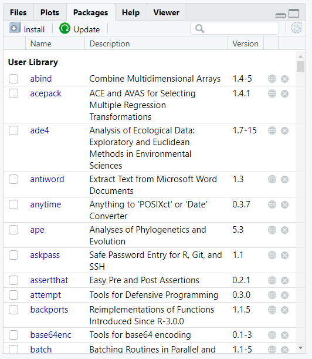

Panneau packages dans RStudio.

⚠️ Il est important de distinguer l’installation des *packages* et leur utilisation à travers la fonction `library()`. l’installation télécharge les *packages* sur internet et les installe localement sur le disque dur de l’ordinateur dans le dossier `R` (Cette opération n’est à réaliser qu’une seule fois). la fonction `library()` permet de faire appel aux fonctions du *package*. Elle doit être appelée à chaque fois que cela est nécessaire.

⚠️ Lors d’une nouvelle installation de R, vous serez amené à télécharger un grand nombre de packages.

⚠️ Lors de l’installation des packages par le **panneau Packages** (ou la fonction `install.packages`) sous Windows et MacOs, le message `There are binary versions available but the source versions are later` peut aparaître suivi de la question `Do you want to install from sources the package which needs compilation?` Cela signifie que le package a été mis à jour récemment sur CRAN mais que le binaire n’est pas encore disponible pour votre système d’exploitation. En effet, certains packages R ont des parties importantes écrites dans d’autres langages compilés, généralement C / C ++ ou Fortran. Ces langages ont besoin d’outils logiciels accessoires pour traduire (“compiler”) leur code source en langage machine qui peut s’exécuter sur un système particulier.  
Pour Windows et MacOs, l’auteur d’un package met à disposition des binaires précompilés et ils peut avoir un délais entre leur mise à disposition pour MacOs et Windows. Ainsi, vous ne pouvez que répondre *non* à la question posée et n’obtiendrez pas la version la plus récente. Vous devrez patienter afin d’attendre une mise en ligne, sauf à forcer et l’installer à partir de la source ( ensemble de dépendances logicielles appelées " RTools ").

# Se repérer dans RStudio

## Quelques repères indispensables pour débuter

- **Le gestionnaire de projet** : assure la gestion des fichiers liés à une session en R.
- **La console** : zone de dialogue directe avec R (entrées, sorties).
- **Le panneau source** :
  - zone d’écriture de scripts (fichiers de type texte dans lequel il est possible de saisir directement une séquence d’instructions pour l’exécuter par la suite).
  - Zone d’écriture de documents en R Markdown.
- **L’environnement (*environment*)** :
  - Permet l’importation de tableaux de données.
  - Gère les objets en mémoire (Workspace) (List, Grid, Clear).
- **Le répertoire de travail (*files*)** : zone d’affichage du répertoire de travail.
- **Le gestionnaire de packages (*packages*)** : gère les packages (téléchargements, mises à jour)
- **Graphiques et visualisation (*plots & viewer*)** : Affichage de sorties.

## Organiser ses fichiers dans un projet

Une session de R pointe systématiquement vers un répertoire définit par l’utilisateur comme répertoire de travail (**working directory**) pour y lire ou écrire des données stockées dans différents fichiers. En pratique, on associe tous les fichiers relatifs à un même ojbet de travail à un répertoire dédié. RStudio facilite cette gestion avec les “projets”.

- Créer un projet :
  - Etape 1 : ouvrez RStudio
  - Etape 2 : menu **project > New project > Directory name** : nom du répertoire > > as subdirectory of U:
- Ouvrir et fermer un projet :
  - Ouverture depuis le gestionnaire de fichier du système d’exploitation (ex : Windows) : cliquez sur le fichier **.Rproj**.
  - Fermeture (RStudio : **Menu file > quit session**). ⚠️ L’option **Save workspace** permet de sauvegarder les objets présents dans l’environnement.

## Console et scripts

Un ordinateur assure des opérations de traitement de l’information qu’il exécute successivement. Ce traitement est mené à l’aide d’instructions.Un programme informatique est constitué d’une suite d’instructions dont l’assemblage dans un ordre précis, R exécutant les instructions de manière séquentielle, conduit au résultat attendu.

On utilise la **console** lorsqu’il s’agit de saisir des instructions isolées et les **scripts** lorsque l’on écrit un programme.

### Comment saisir une instruction dans la console ?

- Une instruction est saisie dans la **console** à droite de **l’invite** (chevron >).
- Elle est évaluée par la touche **Entrée**.
- Vous pouvez utiliser les flèches haut et bas pour naviguer dans l’historique des commandes que vous avez tapées précédemment.
- Lorsqu’une instruction est incomplète la console affiche le signe **+** signifiant que R “attend la suite” :
  - On peut alors compléter l’instruction sur cette nouvelle ligne et valider par **Entrée**.
  - Tout annuler et revenir à l’invite de commandes normal en appuyant sur la touche **Échap**.

### Comment saisir une instruction dans un script ?

- On crée un script par le menu **File > New file > R Script**.
- On peut exécuter une séquence d’instruction en la sélectionnant et on valide par **Run** ou **Ctrl + Entrée**.
- On peut exécuter la totalité du script par **Source (Ctrl + maj + s)** ou **Source with Echo (Ctrl + maj + Entrée)** qui exécute le programme comme si vous aviez copié chaque ligne dans la console.

# Quelques bases du langage

## Des instructions simples : les expressions arithmétiques

```r
50 + 80 + 200
```

```
## [1] 330
```

```r
(50 + 80 + 200)/3
```

```
## [1] 110
```

- R utilise le **point** comme séparateur décimal.
- R utilise les signes opératoires **+, -, *, / et ^** et les parenthèses.

## Utiliser les variables

- Les variables permettent de stocker des informations dans la mémoire de l’ordinateur.
- Pour employer une image, une variable est une boîte, que l’ordinateur va repérer par une étiquette. Pour avoir accès au contenu de la boîte, il suffit de la désigner par son étiquette.
- Quand on créé une variable “vide” on parle de *déclaration* en spécifiant son nom.
- Quand on attribue une valeur à une variable, on parle *d’affectation*.
- L’affectation se lit de droite à gauche.
- Les instructions situées à droite du signe **flèche** sont affectées à une variable désignée par un nom.
- La flèche est saisie par le raccourcis clavier **Alt-6**.

```r
# Exemple de déclaration
var1 <-c()
```

```r
# Exemples d'affectations
var2 <- 4192
var3 <- 50 + 80 + 200
var4 <- "Jean Simon"
```

## Afficher le contenu d’une variable

```r
print(var3)     # Affichage du contenu de la variable exp_fr.
```

```
## [1] 330
```

```r
var3            # Ou tout simplement...
```

```
## [1] 330
```

## Supprimer une variable

```r
rm(var4)
```

## Réaffecter une valeur à une variable

Il est permis de ré-affecter une nouvelle valeur à une même variable.

```r
var2 <- 4192
var2 <- 6000
var2
```

```
## [1] 6000
```

- Une variable possède à un moment donné une valeur et une seule.
- Quand on assigne une nouvelle valeur à une variable déjà existante, la valeur précédente est perdue.

## Exemple de séquence d’instructions

Programme permettant d’échanger les valeurs de deux variables x et y, et ce quel que soit leur contenu préalable.

```r
x <- 3
y <- 5
print (x)
```

```
## [1] 3
```

```r
print (y)
```

```
## [1] 5
```

```r
z <- x
x <- y
y <- z

print (x)
```

```
## [1] 5
```

```r
print (y)
```

```
## [1] 3
```

## Découvrir les vecteurs

- Un vecteur est un objet qui contient des éléments de type identique.
- Les vecteurs peuvent être construits en combinant des éléments grâce à l’importante fonction `c()` (*combine*).
- Les vecteurs peuvent générer des séquences de nombres.
- La position d’un élément d’un vecteur est appelé position d’index. Elle est noté par un nombre entre crochet. Ainsi le 19e élément du vecteur `chrono` et `1532` et le 20e, `1533`.

```r
# Vecteur textuel
ports_bretons <- c("Nantes", "Brest", "Saint-Malo", "Vannes")
ports_bretons
```

```
## [1] "Nantes"     "Brest"      "Saint-Malo" "Vannes"
```

```r
# Vecteur numérique
chrono <- 1514:1866
chrono
```

```
##   [1] 1514 1515 1516 1517 1518 1519 1520 1521 1522 1523 1524 1525 1526 1527 1528
##  [16] 1529 1530 1531 1532 1533 1534 1535 1536 1537 1538 1539 1540 1541 1542 1543
##  [31] 1544 1545 1546 1547 1548 1549 1550 1551 1552 1553 1554 1555 1556 1557 1558
##  [46] 1559 1560 1561 1562 1563 1564 1565 1566 1567 1568 1569 1570 1571 1572 1573
##  [61] 1574 1575 1576 1577 1578 1579 1580 1581 1582 1583 1584 1585 1586 1587 1588
##  [76] 1589 1590 1591 1592 1593 1594 1595 1596 1597 1598 1599 1600 1601 1602 1603
##  [91] 1604 1605 1606 1607 1608 1609 1610 1611 1612 1613 1614 1615 1616 1617 1618
## [106] 1619 1620 1621 1622 1623 1624 1625 1626 1627 1628 1629 1630 1631 1632 1633
## [121] 1634 1635 1636 1637 1638 1639 1640 1641 1642 1643 1644 1645 1646 1647 1648
## [136] 1649 1650 1651 1652 1653 1654 1655 1656 1657 1658 1659 1660 1661 1662 1663
## [151] 1664 1665 1666 1667 1668 1669 1670 1671 1672 1673 1674 1675 1676 1677 1678
## [166] 1679 1680 1681 1682 1683 1684 1685 1686 1687 1688 1689 1690 1691 1692 1693
## [181] 1694 1695 1696 1697 1698 1699 1700 1701 1702 1703 1704 1705 1706 1707 1708
## [196] 1709 1710 1711 1712 1713 1714 1715 1716 1717 1718 1719 1720 1721 1722 1723
## [211] 1724 1725 1726 1727 1728 1729 1730 1731 1732 1733 1734 1735 1736 1737 1738
## [226] 1739 1740 1741 1742 1743 1744 1745 1746 1747 1748 1749 1750 1751 1752 1753
## [241] 1754 1755 1756 1757 1758 1759 1760 1761 1762 1763 1764 1765 1766 1767 1768
## [256] 1769 1770 1771 1772 1773 1774 1775 1776 1777 1778 1779 1780 1781 1782 1783
## [271] 1784 1785 1786 1787 1788 1789 1790 1791 1792 1793 1794 1795 1796 1797 1798
## [286] 1799 1800 1801 1802 1803 1804 1805 1806 1807 1808 1809 1810 1811 1812 1813
## [301] 1814 1815 1816 1817 1818 1819 1820 1821 1822 1823 1824 1825 1826 1827 1828
## [316] 1829 1830 1831 1832 1833 1834 1835 1836 1837 1838 1839 1840 1841 1842 1843
## [331] 1844 1845 1846 1847 1848 1849 1850 1851 1852 1853 1854 1855 1856 1857 1858
## [346] 1859 1860 1861 1862 1863 1864 1865 1866
```

## Utiliser les fonctions existantes

Une fonction est programmée pour accomplir une tâche et retourner un résultat. Les composantes d’une fonction sont son nom, c’est ce nom qui nous permettra de nous y référer et un ou plusieurs arguments, informations nécessaires à la fonction (entre parenthèses et séparés par le signe virgule).

A titre d’exemple, la fonction `sample`permet de tirer un échantillon au sein d’un vecteur. Elle prend comme arguments le nom du vecteur ainsi que la taille de l’échantillon.Certains arguments possèdent des valeurs par défaut et n’ont besoins d’être précisés uniquement si l’on souhait être plus explicite ou si on cherche à modifier cette valeur. Ainsi, l’instruction `sample(chrono,1, replace = FALSE)` equivant à `sample(chrono,1)`.

```r
sample(chrono,1)
```

```
## [1] 1645
```

```r
sample(chrono,3)
```

```
## [1] 1525 1662 1515
```

```r
sample(chrono,1, replace = TRUE)
```

```
## [1] 1660
```

```r
sample(chrono,1, replace = FALSE)
```

```
## [1] 1707
```

## Imbrication

Il est possible d’imbriquer des fonctions dans une instruction : **fonction1(fonction2())**

```r
sort(toupper(ports_bretons))
```

```
## [1] "BREST"      "NANTES"     "SAINT-MALO" "VANNES"
```

## Fonctions de base et fonction de packages

- Il convient de distinguer les fonctions de R {Base} et les fonctions des *packages*.
- Une fonction de R {Base} peut ne pas fonctionner au sein d’instructions basées sur des packages.
- Des fonctions de packages peuvent se substituer à des fonctions de R {Base}.

## Recommandations

Les principales fonctions utilisées en td doivent être maîtrisées.

## Découvrir quelques fonctions existantes

## A vous ! Quelles tâches accomplissent les fonctions suivantes ?

```r
x <- "Nantes"
y <- "France"
nchar(x)
paste(x, y, sep =", ")
```

```r
chrono <- 1514:1866
length(chrono)
```

## Quelles tâches accomplissent les fonctions suivantes ? (correction)

```r
x <- "Nantes"
y <- "France"
nchar(x)
```

```
## [1] 6
```

```r
paste(x, y, sep =", ")
```

```
## [1] "Nantes, France"
```

```r
toupper(x)
```

```
## [1] "NANTES"
```

## Quelles tâches accomplissent les fonctions suivantes ? (correction)

- nchar : compte le nombre de caractères.
- paste : concaténation, procédé qui permettant de coller bout à bout différentes chaînes de caractères pour n’en faire plus qu’une seule.
- toupper: conversion en majuscules.

## Quelles tâches accomplissent les fonctions suivantes ? (correction)

```r
chrono <- 1514:1866
length(chrono)
```

```
## [1] 353
```

length : longueur du vecteur (nombre d’élements contenus dans le vecteur).

## A vous ! Imbriquer des fonctions

Concatenez (séparateur tiret) et convertissez en majuscules x, y et z dans la même instruction.

```r
x <- "Dauphin"
y <- "Le Page, Louis"
z <- "France"
```

## Imbriquer des fonctions (correction)

```r
x <- "Dauphin"
y <- "Le Page, Louis"
z <- "France"
```

```r
toupper(paste(x, y, z, sep = " - "))
```

```
## [1] "DAUPHIN - LE PAGE, LOUIS - FRANCE"
```

## A vous ! identifier des fonctions existantes

Trouvez une fonction sur le R base Sheetcheat permettant d’arrondir au dixième le quotient de $\frac{4850}{26}$.

## identifier des fonctions existantes (correction)

```r
round(4850/26, 1)
```

```
## [1] 186.5
```

# Règles et conventions de syntaxe

## Règles de déclaration

- Les noms des variables doivent impérativement commencer par une lettre :

```r
1850 <- 1850        # Erreur de déclaration
annee1850 <- 1850        # Syntaxe correcte
```

- La casse est significative :

```r
Nantes <- 150
# différent de...
nantes <- 550
```

- Le langage lui-même se réserve des termes. Ils sont inutilisables comme noms de variables.

```r
sum <- 250 + 255 + 567    # Erreur de déclaration
somme <- 250 + 255 + 567    # Syntaxe correcte
```

## Conventions de déclaration adoptées en td

1. Tout en minuscule, séparation par un trait de soulignement (*snake_case* ) :

```r
ntes_exp_xviie # OK
NtesExpXVIIe # non
```

2. Eviter les caractères accentués et les symboles.
3. Faire court !

```r
jeu_de_donnees
dataset         # A privilégier
```

```r
france_esclaves_expeditions
fr_esc_exp  # A privilégier
```

## Conventions de style

- Faire précéder et suivre les opérateurs par un espace :

```r
2 + 2
```

- Faire suivre une virgule par un espace :

```r
c(1, 5)
```

- Placer un espace avant et après le symbole d’affectation :

```r
a <- 3
```

- Ne pas placer d’espace entre une fonction et une parenthèse ouvrante :

```r
sum(2, 5)
```

# Commenter ses instructions

# Commenter une instruction

- Les commentaires sont utilisés pour annoter le code.
- Les commentaires sont ignorés par Rr.

## Exemple

```r
# Commentaire en pleine ligne
sort(c(4, 1, 3, 2))

sort(c(4, 1, 3, 2))  # Commentaire court en fin de ligne
```

- N’excédez 80 caractères par ligne, commentaires inclus pour une question de lisibilité.
- R ne gère pas les commentaires multilignes